# Survival Analysis (in-progress)

Giancarlo D’Agostino

2026-03-13

## Survival Analysis

Now let’s try to fit a Kaplan-Meier curve to the people with tuberculosis mentioned in their record.

Start by finding the first date that is associated with a mention of TB

```r
all$recidnum <- as.character(all$recidnum)

tb_date_date <- remove_blank(all) |>
  select(recidnum,
    #a_clm01_date = appdt01,
    #a_clm02_date = appdt02,
    #a_clm03_date = appdt03,
    #a_clm04_date = appdt04,
    #a_clm05_date = appdt05,
    #a_clm07_date = appdt07,
    #a_clm08_date = appdt08,
    #a_clst01_date = appdt01,
    #a_clst02_date = appdt02,
    #a_clst07_date = appdt07,
    #afdesc01_date = infodt01,
    #afdesc02_date = infodt02,
    #afdesc07_date = infodt07,
    dschrn01_date = dschdt01,
dschrn02_date = dschdt02,
dschrn03_date = dschdt03,
dschrn04_date = dschdt04,
dschrn05_date = dschdt05,
dschrn07_date = dschdt07,
dschrn08_date = dschdt08,
dschrn09_date = dschdt09,
dschrn10_date = dschdt10,
dschrn11_date = dschdt11,
dschrn12_date = dschdt12,
dschrn13_date = dschdt13,
dschrn14_date = dschdt14,
dschrn16_date = dschdt16,
dschrn19_date = dschdt19,
dschrn20_date = dschdt20,
ilwdsc01_date = admtdt01,
ilwdsc02_date = admtdt02,
ilwdsc03_date = admtdt03,
ilwdsc04_date = admtdt04,
ilwdsc05_date = admtdt05,
ilwdsc06_date = admtdt06,
ilwdsc07_date = admtdt07,
ilwdsc08_date = admtdt08,
ilwdsc09_date = admtdt09,
ilwdsc10_date = admtdt10,
ilwdsc11_date = admtdt11,
ilwdsc12_date = admtdt12,
ilwdsc13_date = admtdt13,
ilwdsc14_date = admtdt14,
ilwdsc15_date = admtdt15,
ilwdsc16_date = admtdt16,
ilwdsc17_date = admtdt17,
ilwdsc18_date = admtdt18,
ilwdsc19_date = admtdt19,
ilwdsc20_date = admtdt20,
othrrn01_date = othrdt01,
othrrn02_date = othrdt02,
unftc1_1_date = dchdt1_1,
unftc1_2_date = dchdt1_2,
unftc1_3_date = dchdt1_3,
unftc2_1_date = dchdt2_1
  ) |>
  mutate(across(-recidnum, as.character))


tb_date_event <- remove_blank(all) |>
  select(recidnum,
dschrn01,
dschrn02,
dschrn03,
dschrn04,
dschrn05,
dschrn07,
dschrn08,
dschrn09,
dschrn10,
dschrn11,
dschrn12,
dschrn13,
dschrn14,
dschrn16,
dschrn19,
dschrn20,

ilwdsc01,
ilwdsc02,
ilwdsc03,
ilwdsc04,
ilwdsc05,
ilwdsc06,
ilwdsc07,
ilwdsc08,
ilwdsc09,
ilwdsc10,
ilwdsc11,
ilwdsc12,
ilwdsc13,
ilwdsc14,
ilwdsc15,
ilwdsc16,
ilwdsc17,
ilwdsc18,
ilwdsc19,
ilwdsc20,

othrrn01,
othrrn02,

unftc1_1,
unftc1_2,
unftc1_3,
unftc2_1
  )



# Lengthen the dataset and identify pairs

event_long <- tb_date_event |>
  pivot_longer(
    cols = -recidnum,
    names_to = "slot",
    values_to = "event"
  )

date_long <- tb_date_date |>
  pivot_longer(
    cols = -recidnum,
    names_to = "slot",
    values_to = "date"
  ) |>
  mutate(slot = str_remove(slot, "_date$"))

tb_long <- event_long |>
  inner_join(date_long, by = c("recidnum", "slot"), relationship = "many-to-many")

tb_dates <- tb_long |>
  filter(
    !is.na(event),
    str_detect(event, regex("TUBER|CONSUMP|PHTH", ignore_case = TRUE))
  ) |>
  group_by(recidnum) |>
  summarise(
    tb_dates = list(date),
    .groups = "drop"
  )


###### And then join everything back to tb

tb_min_dates <- tb_dates |>
  mutate(
    tb_dates_clean = map(tb_dates, ~ .x[!is.na(.x) & .x != ""]),
    # Replace trailing "--" with "15"
    tb_dates_clean = map(tb_dates_clean, ~ str_replace(.x, "--$", "15")),
    # Keep only valid 8-digit dates
    tb_dates_clean = map(tb_dates_clean, ~ .x[str_detect(.x, "^\\d{8}$")]),
    # Get earliest date
    tb_first_date = map_chr(tb_dates_clean, ~ if(length(.x) == 0) NA_character_ else min(.x))
  ) |>
  select(recidnum, tb_first_date)

tb_min_dates$recidnum <- as.character(tb_min_dates$recidnum)

first_tb_full <- all |>
  left_join(tb_min_dates, by = "recidnum") |>
  select(recidnum,
         BYR,
         DYR,
         tb_first_date,
         TB_yn,

         # For later matching **ADD HEIGHT
         initstat, initreg, gen_birthplace_icpsr1, wnd_yn
         )
```

Now let’s get a data frame with relevant date by recruit

```r
first_tb_full <- first_tb_full |>
  mutate(recidnum = as.character(recidnum))

first_tb_full <- first_tb_full |>
  mutate(
    tb_first_date = substr(tb_first_date, 1, 4)
  )

first_tb_full <- remove_blank(first_tb_full) |>
  mutate(
    DYR = as.numeric(DYR),
    tb_first_date = as.numeric(tb_first_date)
  )

# Prepare dataset for survival curve
surv_tb <- first_tb_full |>
  mutate(
    age_tb = tb_first_date - BYR,
    age_death = DYR - BYR
  )

# From the future: Saving for new matching document
saveRDS(surv_tb, file = "../data/in-progress/surv_tb.RDS")
```

And plot!

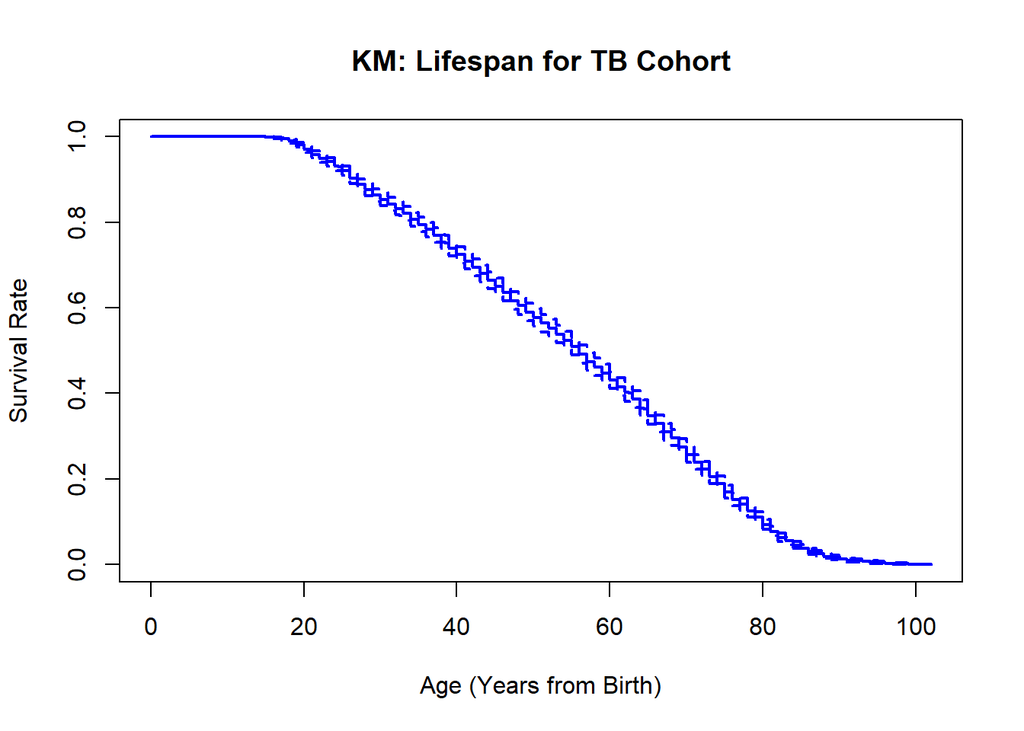

```r
library(survival)
library(dplyr)

# ---- MODEL 1: -----#

tb_cohort <- surv_tb |>
  filter(TB_yn  == "1")

# Right-censored survival object (referencing the columns inside the dataframe)
tb_cohort_clean <- tb_cohort |>
  mutate(
    # Ensure columns are numeric; handle potential Date objects
    lifespan = as.numeric(age_death),
    # Everyone is dead in this study
    death_event = 1
  ) |>
  filter(!is.na(lifespan) & lifespan > 0 & lifespan < 120)

# Fit Kaplan-Meier
km_fit_lifespan <- survfit(Surv(lifespan, death_event) ~ 1, data = tb_cohort_clean)

# Base R plot
plot(km_fit_lifespan,
     conf.int = T,
     xlab = "Age (Years from Birth)",
     ylab = "Survival Rate",
     main = "KM: Lifespan for TB Cohort",
     col = "blue",
     lwd = 2)
```

```r
print(km_fit_lifespan)
```

```
## Call: survfit(formula = Surv(lifespan, death_event) ~ 1, data = tb_cohort_clean)
##
##         n events median 0.95LCL 0.95UCL
## [1,] 2280   2280     56      55      57
```

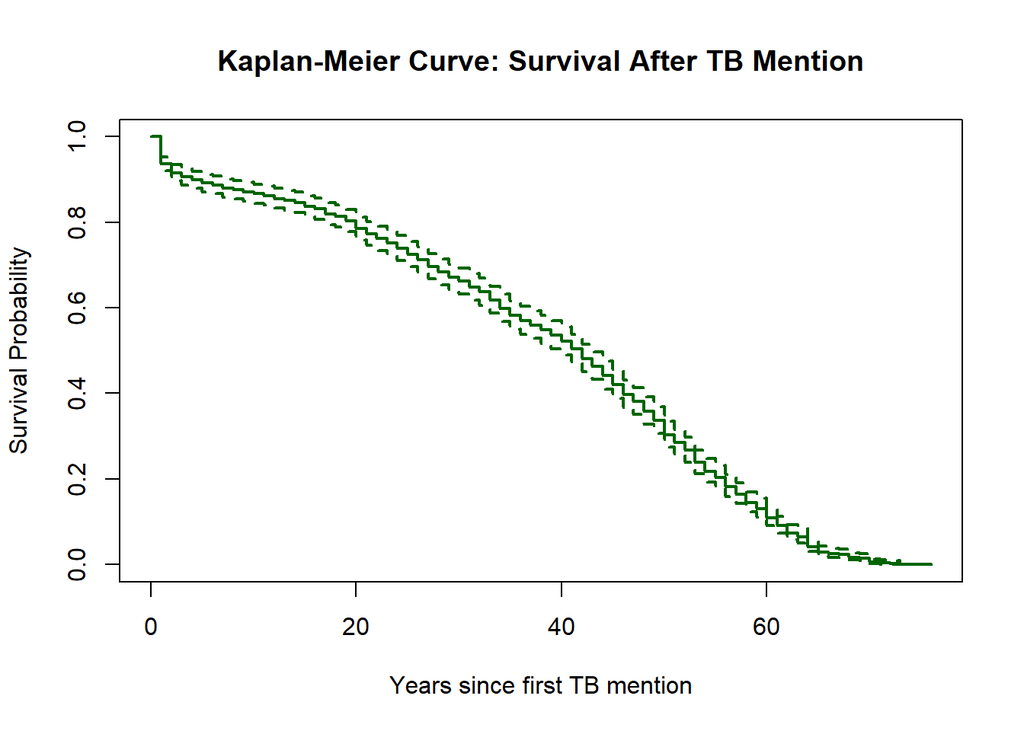

```r
#-------- MODEL 2 ----------#

# Calculate time since TB mention and censoring
surv_tb_2 <- first_tb_full |>
  filter(!is.na(tb_first_date) & !is.na(DYR) & !is.na(BYR) & TB_yn == "1") |>
  mutate(
    start_age = as.numeric(tb_first_date) - as.numeric(BYR),
    end_age   = as.numeric(DYR) - as.numeric(BYR),
    time_since_tb = end_age - start_age,
    event = 1
  ) |>
  # Filter out 0 or negative time (may cause plotting artifacts)
  filter(time_since_tb > 0)


km_fit_post <- survfit(Surv(time_since_tb, event) ~ 1, data = surv_tb_2)

plot(km_fit_post,
     conf.int = TRUE,
     col = "darkgreen",
     lwd = 2,
     xlab = "Years since first TB mention",
     ylab = "Survival Probability",
     main = "Kaplan-Meier Curve: Survival After TB Mention",
     ylim = c(0, 1))
```

```r
print(km_fit_post)
```

```
## Call: survfit(formula = Surv(time_since_tb, event) ~ 1, data = surv_tb_2)
##
##        n events median 0.95LCL 0.95UCL
## [1,] 893    893     42      40      43
```

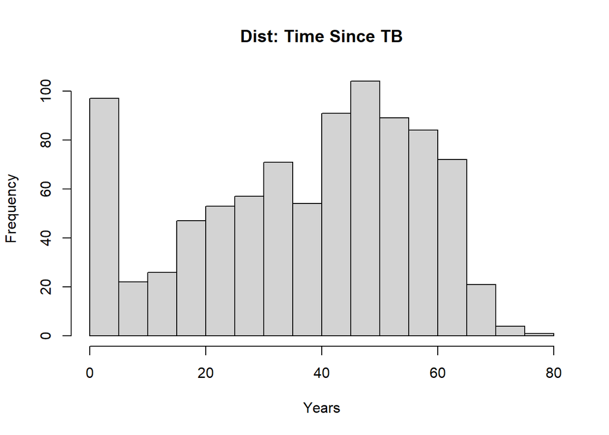

```r
hist(as.numeric(surv_tb_2$time_since_tb), main = "Dist: Time Since TB", xlab = "Years")
```

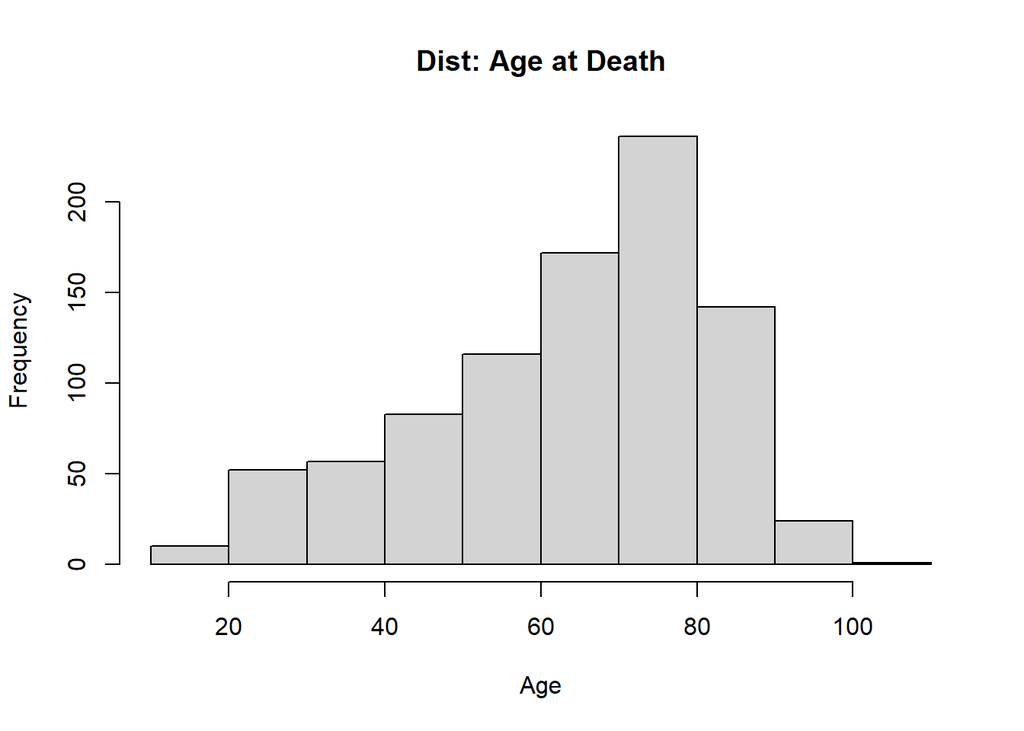

```r
hist(as.numeric(surv_tb_2$end_age), main = "Dist: Age at Death", xlab = "Age")
```

To be able to compare TB to non-TB soldiers, we need to evaluate survival from a common event. Let’s do first enlistment, which will control for time spent in the army.

```r
lst <- all |>
  select(recidnum,
    lstdt1_1, mildfdt1, lstdt1_2, mildfdt2,
    lstdt1_3, mildfdt3, lstdt2_1, mildfdt4,
    lstdt2_2, mildfdt5, lstdt2_3, mildfdt6,
    TB_yn, DYR
  )

lst <- as.data.frame(t(apply(remove_blank(lst), 1, cln_dupl)))



# Turn end "--" into 0 and delete every cell that still has "--" to get rid of dates that are too arbitrary (month or year is unknown)

lst <- lst |>
  mutate(
    across(-c(recidnum, TB_yn), ~gsub("--$", "00", .)),
    across(-c(recidnum, TB_yn), ~if_else(grepl("--", .x), NA, .x)),
    across(-c(recidnum, TB_yn), ~ifelse(!is.na(.x), substr(.x, 1, 4), .x))
  ) |>
  filter(if_any(-c(recidnum, TB_yn), ~ !is.na(.x))) |>
  rowwise() |>
  mutate(
    first_lst = min(c_across(-c(recidnum,TB_yn)), na.rm = TRUE)
  ) |>
  ungroup()


# And new lets see the Kaplan-Meier curve for TB versus non-TB

compare_df <- lst |>
  mutate(
    first_lst = as.numeric(first_lst),
    DYR = as.numeric(DYR),
    surv_time = DYR - first_lst,
    event = 1
  ) |>
  filter(surv_time >= 0)

compare_df$TB_yn <- factor(compare_df$TB_yn,
                           levels = c(0, 1),
                           labels = c("Non-TB", "TB"))


km_comparison <- survfit(Surv(surv_time, event) ~ TB_yn, data = compare_df)

print(km_comparison)
```

```
## Call: survfit(formula = Surv(surv_time, event) ~ TB_yn, data = compare_df)
##
##                  n events median 0.95LCL 0.95UCL
## TB_yn=Non-TB 25506  25506     41      40      41
## TB_yn=TB      2283   2283     29      28      30
```

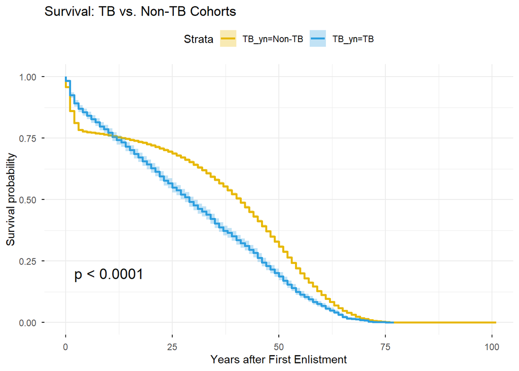

```r
p <- ggsurvplot(
  km_comparison,
  data = compare_df,
  conf.int = TRUE,
  risk.table = FALSE,
  pval = TRUE,
  palette = c("#E7B800", "#2E9FDF"),
  xlab = "Years after First Enlistment",
  ggtheme = theme_minimal()
)

p$plot <- p$plot + labs(title = "Survival: TB vs. Non-TB Cohorts")

p
```

As you can see, the tb vs. non-tb survival curves are significantly different (P < 0.0001 for log rank test).

The log rank test requires that: - the censoring patterns are the same - the hazard functions for the two groups are proportional

We want to see if their is any causal relationship between the diagnosis of tb. To do this, we will match TB individuals to non-TB individuals with as many of the same characteristics as possible. The characteristics we will try to match are:

- Birth Year
- US State of enlistment

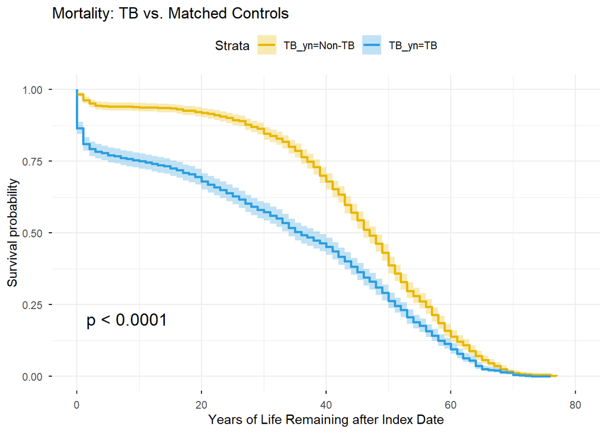

```r
# Characteristics

# Dataframe for matching from the previous time_since_tb dataframe

match_full <- surv_tb |>
  select(
    recidnum,
    tb_first_date, age_tb, age_death,
    BYR, DYR, initstat, TB_yn
  ) |>
  filter(
    if_all(c(BYR), is.finite)
  ) |>
  mutate(
    TB_yn = as.numeric(as.character(TB_yn))
  ) |>
  drop_na(initstat)


match_full <- matchit(TB_yn ~ BYR + initstat,
                      data = match_full,
                      distance = "glm",
                      link = "probit")

matched_df <- match.data(match_full)


# Add constant status for lack of censoring
matched_df$status <- 1

# Create index date for non-TB
matched_df <- matched_df |>
  group_by(subclass) |>
  mutate(
    index_date = max(tb_first_date, na.rm = T)
  ) |>
  ungroup() |>
  mutate(
    index_date = if_else(is.infinite(index_date), NA_real_, index_date)
  ) |>
  drop_na(index_date) |>
  mutate(
    survival_time = DYR - index_date
  ) |>
  drop_na(survival_time) |>
  filter(survival_time >= 0)

# Final formatting of the matched data
plot_df <- matched_df |>
  mutate(
    event = 1
  ) |>
  mutate(TB_yn = factor(TB_yn,
                        levels = c(0, 1),
                        labels = c("Non-TB", "TB")))

# Fit km model
km_matched <- survfit(Surv(survival_time, event) ~ TB_yn, data = plot_df)

matched_p_final <- ggsurvplot(
  km_matched,
  data = plot_df,
  conf.int = TRUE,
  risk.table = FALSE,
  pval = TRUE,
  palette = c("#E7B800", "#2E9FDF"),
  xlab = "Years of Life Remaining after Index Date",
  ggtheme = theme_minimal()
)

matched_p_final$plot <- matched_p_final$plot +
  labs(title = "Mortality: TB vs. Matched Controls")

matched_p_final
```

```r
# And table for the median survival times

medians <- surv_median(km_matched)

median_table <- medians |>
  mutate(
    Group = gsub("TB_tn=", "", strata),
    Median_Years = round(median, 2),
    Lower_95_CI = round(lower, 1),
    Upper_95_CI = round(upper, 1)
  ) |>
  select(Group, Median_Years, Lower_95_CI, Upper_95_CI)

print(median_table)
```

```
##          Group Median_Years Lower_95_CI Upper_95_CI
## 1 TB_yn=Non-TB           47          46          48
## 2     TB_yn=TB           36          34          39
```

Now, to add more characteristics to matching:

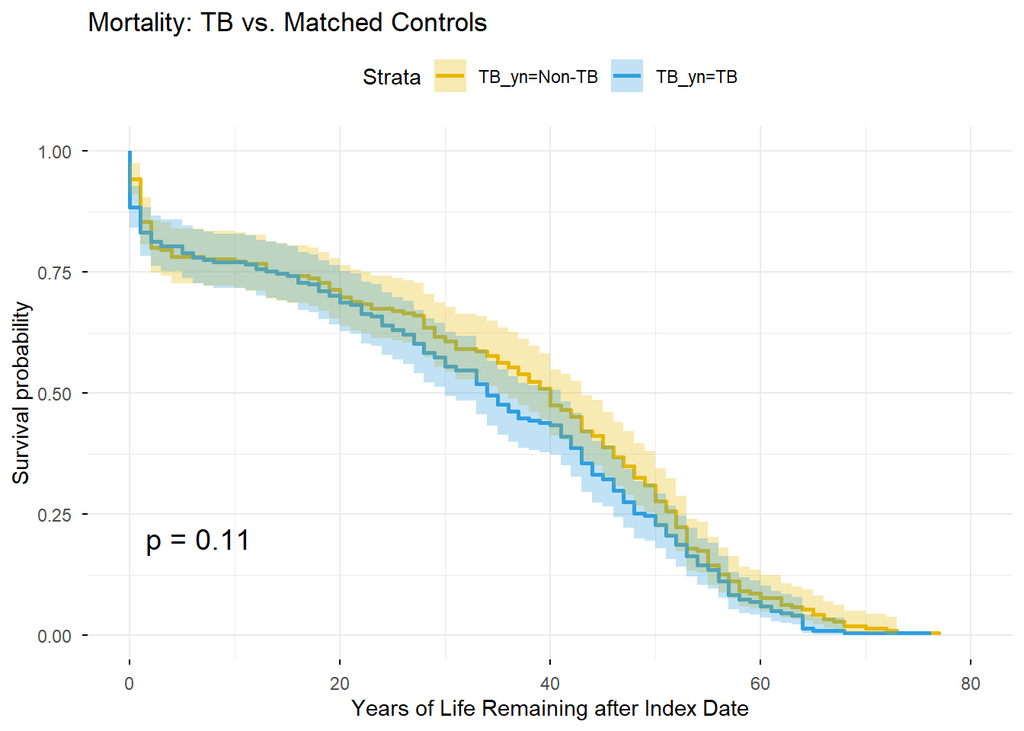

```r
match_full <- surv_tb |>
  select(
    recidnum,
    tb_first_date, age_tb, age_death,
    BYR, DYR, initstat, initreg, gen_birthplace_icpsr1, wnd_yn,
    TB_yn
  ) |>
  filter(
    if_all(c(BYR), is.finite)
  ) |>
  mutate(
    TB_yn = as.numeric(as.character(TB_yn))
  ) |>
  drop_na(initstat, initreg, DYR, gen_birthplace_icpsr1)


match_full <- matchit(TB_yn ~ BYR + gen_birthplace_icpsr1 + initreg + wnd_yn,
                      data = match_full,
                      method = "nearest",
                      distance = "glm",
                      link = "probit",
                      exact = ~initreg)


matched_df <- match.data(match_full)

# Add constant status for lack of censoring
matched_df$status <- 1

# Create index date for non-TB
matched_df <- matched_df |>
  group_by(subclass) |>
  mutate(
    index_date = if_else(
      any(!is.na(tb_first_date)),
      max(tb_first_date, na.rm = TRUE),
      NA_real_
    )
  ) |>
  ungroup() |>
  drop_na(index_date) |>
  mutate(
    survival_time = DYR - index_date
  ) |>
  drop_na(survival_time) |>
  filter(survival_time >= 0)

# Final formatting of the matched data
plot_df <- matched_df |>
  mutate(
    event = 1
  ) |>
  mutate(TB_yn = factor(TB_yn,
                        levels = c(0, 1),
                        labels = c("Non-TB", "TB")))

# Fit km model
km_matched <- survfit(Surv(survival_time, event) ~ TB_yn, data = plot_df)

matched_p_final <- ggsurvplot(
  km_matched,
  data = plot_df,
  conf.int = TRUE,
  risk.table = FALSE,
  pval = TRUE,
  palette = c("#E7B800", "#2E9FDF"),
  xlab = "Years of Life Remaining after Index Date",
  ggtheme = theme_minimal()
)

matched_p_final$plot <- matched_p_final$plot +
  labs(title = "Mortality: TB vs. Matched Controls")

matched_p_final
```

```r
# And table for the median survival times

medians <- surv_median(km_matched)

median_table <- medians |>
  mutate(
    Group = gsub("TB_yn=", "", strata),
    Median_Years = round(median, 2),
    Lower_95_CI = round(lower, 1),
    Upper_95_CI = round(upper, 1)
  ) |>
  select(Group, Median_Years, Lower_95_CI, Upper_95_CI)

# Print clean table
kable(
  median_table,
  caption = "Median Survival Times: TB vs. Matched Controls",
  align = "c",
  col.names = c("Cohort", "Median (Years)", "Lower 95% CI", "Upper 95% CI")
)
```

Median Survival Times: TB vs. Matched Controls

| Cohort | Median (Years) | Lower 95% CI | Upper 95% CI |
| --- | --- | --- | --- |
| Non-TB | 40 | 35 | 43 |
| TB | 34 | 30 | 41 |

```r
# Cox model

cox_fit <- coxph(Surv(survival_time, event) ~ TB_yn, data = plot_df)

summary(cox_fit)
```

```
## Call:
## coxph(formula = Surv(survival_time, event) ~ TB_yn, data = plot_df)
##
##   n= 420, number of events= 420
##
##            coef exp(coef) se(coef)     z Pr(>|z|)
## TB_ynTB 0.15759   1.17069  0.09828 1.604    0.109
##
##         exp(coef) exp(-coef) lower .95 upper .95
## TB_ynTB     1.171     0.8542    0.9656     1.419
##
## Concordance= 0.52  (se = 0.014 )
## Likelihood ratio test= 2.57  on 1 df,   p=0.1
## Wald test            = 2.57  on 1 df,   p=0.1
## Score (logrank) test = 2.58  on 1 df,   p=0.1
```

After evaluating the quality of matching, we decided that this method was not working. We will be going variable by variable in the new document, `03_matching.Rmd`